# Workshop Materials: JSON & jsonlite

[Sangeeth Selvaraju](https://github.com/RajaSangeeth) & [Milan Schröder](https://github.com/milanschroeder)

November 01, 2021 | 17:15:17 | CET

### Get to know the package and data type:

First, we have to load the package:

```r
# if necessary:
# install.packages("jsonlite")
library(jsonlite)
library(tidyverse)
```

First, what does JSON actually look like? We can write own JSON object (just for demonstration):

```r
todays_instructors <-
'[
{
"Name": "Milan",
"Age": 25,
"Programme": "MIA",
"Likes_IDS_class": "true"
},
{
"Name": "Sangeeth",
"Age": 25,
"Programme": "MPP",
"Likes_IDS_class": null
}
]'
```

Remember the chart from our presentation?

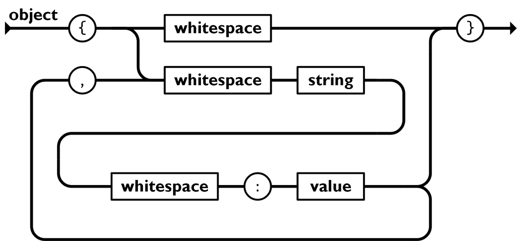

That’s exactly what we did here!

```r
jsonlite::validate(todays_instructors)
```

```
TRUE [1] TRUE
```

```r
# note that if we would e.g. have forgotten some "", it wouldn't be a valid JSON object.
# whitespaces and indentation may be used arbitrarily
```

Our Data is actually a valid JSON object! So let’s see what we can do with that…

```r
print(todays_instructors)
```

```
TRUE [1] "[\n{\n\"Name\": \"Milan\",\n\"Age\": 25,\n\"Programme\": \"MIA\",\n\"Likes_IDS_class\": \"true\"\n},\n{\n\"Name\": \"Sangeeth\",\n\"Age\": 25,\n\"Programme\": \"MPP\",\n\"Likes_IDS_class\": null\n}\n]"
```

Not very easy to read (or use) as raw text… let’s convert it!

# First key command: `fromJSON`

```r
(not_simplified <- jsonlite::fromJSON(todays_instructors,
                                      simplifyDataFrame = F))
```

```
TRUE [[1]]
TRUE [[1]]$Name
TRUE [1] "Milan"
TRUE
TRUE [[1]]$Age
TRUE [1] 25
TRUE
TRUE [[1]]$Programme
TRUE [1] "MIA"
TRUE
TRUE [[1]]$Likes_IDS_class
TRUE [1] "true"
TRUE
TRUE
TRUE [[2]]
TRUE [[2]]$Name
TRUE [1] "Sangeeth"
TRUE
TRUE [[2]]$Age
TRUE [1] 25
TRUE
TRUE [[2]]$Programme
TRUE [1] "MPP"
TRUE
TRUE [[2]]$Likes_IDS_class
TRUE NULL
```

Looks somehow familiar?! It’s basically the structure of a (named) list in R

```r
str(not_simplified)
```

```
TRUE List of 2
TRUE  $ :List of 4
TRUE   ..$ Name           : chr "Milan"
TRUE   ..$ Age            : int 25
TRUE   ..$ Programme      : chr "MIA"
TRUE   ..$ Likes_IDS_class: chr "true"
TRUE  $ :List of 4
TRUE   ..$ Name           : chr "Sangeeth"
TRUE   ..$ Age            : int 25
TRUE   ..$ Programme      : chr "MPP"
TRUE   ..$ Likes_IDS_class: NULL
```

More specifically, it’s a list of 2 which each represent lists of all 4 key-value pairs

…but it’s still rather difficult to access (especially if you want multiple values…)

```r
not_simplified[[1]]$Likes_IDS_class
```

```
TRUE [1] "true"
```

We can transform it to a dataframe manually:

```r
# but we would have to recode null-values before, because they can not be interpreted as arrays usually:
not_simplified[[2]]$Likes_IDS_class <- NA

bind_rows(not_simplified[[1]] %>%
            as_data_frame(),
            not_simplified[[2]] %>%
            as_data_frame())
```

| Name | Age | Programme | Likes_IDS_class |
| --- | --- | --- | --- |
| Milan | 25 | MIA | true |
| Sangeeth | 25 | MPP | NA |

… but that is rather lengthy…

Luckily, `jsonlite` allows us to do all that in just one step, using the `simplify*` options:

Simplification is the process where JSON arrays automatically get converted from a list into a more specific R class. The fromJSON function has 3 arguments which control the simplification process: `simplifyVector`, `simplifyDataFrame` and `simplifyMatrix`. Each one is enabled by default.

```r
(simplified <- jsonlite::fromJSON(todays_instructors,
                                  simplifyDataFrame = T))
```

|  | Name | Age | Programme | Likes_IDS_class |
| --- | --- | --- | --- | --- |
| 1 | Milan | 25 | MIA | true |
| 2 | Sangeeth | 25 | MPP | NA |

… And JSON can store more complex structures like nested objects:

Think of them as lists, that may contain, values, vectors, dataframes, or even other lists.

```r
nested_object <-
'[
{
"value": 42,
"array": [1,2],
"array": [99,98],
"matrix": [[1,2],[3,4]],
"list": {"first": 42,
         "second": 3.141593,
         "last": "MMXXI", "addition":
        {"another list": ["a", "b", "C"]}}
},
{
"something": [99,-10],
"value": 33,
"array": [3,4,5,6]
}
]'

# Note that "array" occurs twice in one object. The second entry is just ignored when converted!
```

But can we change this structure to a dataframe, too?

```r
(nested_df <- fromJSON(nested_object))
```

|  | value | array | matrix | list | something |
| --- | --- | --- | --- | --- | --- |
| 1 | 42 |  |  |  |  |
| 2 | 33 |  |  |  |  |

```r
nested_df$array
```

```
TRUE [[1]]
TRUE [1] 1 2
TRUE
TRUE [[2]]
TRUE [1] 3 4 5 6
```

```r
nested_df$matrix
```

```
TRUE [[1]]
TRUE      [,1] [,2]
TRUE [1,]    1    2
TRUE [2,]    3    4
TRUE
TRUE [[2]]
TRUE NULL
```

```r
nested_df$list
```

|  | first | second | last | addition |
| --- | --- | --- | --- | --- |
| 1 | 42 | 3.141593 | MMXXI |  |
| 2 | NA | NA | NA |  |

```r
jsonlite::flatten(nested_df)
```

|  | value | array | matrix | something | list.first | list.second | list.last | list.addition.another list |
| --- | --- | --- | --- | --- | --- | --- | --- | --- |
| 1 | 42 |  |  |  | 42 | 3.141593 | MMXXI |  |
| 2 | 33 |  |  |  | NA | NA | NA |  |

# Second key command: `toJSON`

We can convert objects from JSON, so of course we also can convert them back:

```r
## Change data frame to JSON
(not_pretty <- starwars %>% slice_sample(n = 3) %>% toJSON(pretty = FALSE)) # that's the default!
```

```
TRUE [{"name":"R4-P17","height":96,"hair_color":"none","skin_color":"silver, red","eye_color":"red, blue","sex":"none","gender":"feminine","species":"Droid","films":["Attack of the Clones","Revenge of the Sith"],"vehicles":[],"starships":[]},{"name":"Dexter Jettster","height":198,"mass":102,"hair_co…
```

```r
(pretty <- starwars %>% slice_sample(n = 3) %>% toJSON(pretty = TRUE)) # but that's much nicer!
```

```
TRUE [
TRUE   {
TRUE     "name": "Luminara Unduli",
TRUE     "height": 170,
TRUE     "mass": 56.2,
TRUE     "hair_color": "black",
TRUE     "skin_color": "yellow",
TRUE     "eye_color": "blue",
TRUE     "birth_year": 58,
TRUE     "sex": "female",
TRUE     "gender": "feminine",
TRUE     "homeworld": "Mirial",
TRUE     "species": "Mirialan",
TRUE     "films": ["Attack of the Clones", "Revenge of the Sith"],
TRUE     "vehicles": [],
TRUE     "starships": []
TRUE   },
TRUE   {
TRUE     "name": "R5-D4",
TRUE     "height": 97,
TRUE     "mass": 32,
TRUE     "skin_color": "white, red",
TRUE     "eye_color": "red",
TRUE     "sex": "none",
TRUE     "gender": "masculine",
TRUE     "homeworld": "Tatooine",
TRUE     "species": "Droid",
TRUE     "films": ["A New Hope"],
TRUE     "vehicles": [],
TRUE     "starships": []
TRUE   },
TRUE   {
TRUE     "name": "Shmi Skywalker",
TRUE     "height": 163,
TRUE     "hair_color": "black",
TRUE     "skin_color": "fair",
TRUE     "eye_color": "brown",
TRUE     "birth_year": 72,
TRUE     "sex": "female",
TRUE     "gender": "feminine",
TRUE     "homeworld": "Tatooine",
TRUE     "species": "Human",
TRUE     "films": ["Attack of the Clones", "The Phantom Menace"],
TRUE     "vehicles": [],
TRUE     "starships": []
TRUE   }
TRUE ]
```

# See it in Action

Let’s try it out, using the ([GitHub API](https://api.github.com/)):

```r
(workshops = jsonlite::fromJSON("https://api.github.com/orgs/intro-to-data-science-21-workshop/repos"))
```

|  | id | node_id | name | full_name | private | owner | html_url | description | fork | url | forks_url | keys_url | collaborators_url | teams_url | hooks_url | issue_events_url | events_url | assignees_url | branches_url | tags_url | blobs_url | git_tags_url | git_refs_url | trees_url | statuses_url | languages_url | stargazers_url | contributors_url | subscribers_url | … |
| --- | --- | --- | --- | --- | --- | --- | --- | --- | --- | --- | --- | --- | --- | --- | --- | --- | --- | --- | --- | --- | --- | --- | --- | --- | --- | --- | --- | --- | --- | --- |
| 1 | 414358050 | R_kgDOGLKaIg | workshop-presentations | intro-to-data-science-21-workshop/workshop-presentations | FALSE |  | https://github.com/intro-to-data-science-21-workshop/workshop-presentations | NA | FALSE | https://api.github.com/repos/intro-to-data-science-21-workshop/workshop-presentations | https://api.github.com/repos/intro-to-data-science-21-workshop/workshop-presentations/forks | https://api.github.com/repos/intro-to-data-science-21-workshop/workshop-presentations/keys{/key_id} | https://api.github.com/repos/intro-to-data-science-21-workshop/workshop-presentations/collaborators{/collaborator} | https://api.github.com/repos/intro-to-data-science-21-workshop/workshop-presentations/teams | https://api.github.com/repos/intro-to-data-science-21-workshop/workshop-presentations/hooks | https://api.github.com/repos/intro-to-data-science-21-workshop/workshop-presentations/issues/events{/number} | https://api.github.com/repos/intro-to-data-science-21-workshop/workshop-presentations/events | https://api.github.com/repos/intro-to-data-science-21-workshop/workshop-presentations/assignees{/user} | https://api.github.com/repos/intro-to-data-science-21-workshop/workshop-presentations/branches{/branch} | https://api.github.com/repos/intro-to-data-science-21-workshop/workshop-presentations/tags | https://api.github.com/repos/intro-to-data-science-21-workshop/workshop-presentations/git/blobs{/sha} | https://api.github.com/repos/intro-to-data-science-21-workshop/workshop-presentations/git/tags{/sha} | https://api.github.com/repos/intro-to-data-science-21-workshop/workshop-presentations/git/refs{/sha} | https://api.github.com/repos/intro-to-data-science-21-workshop/workshop-presentations/git/trees{/sha} | https://api.github.com/repos/intro-to-data-science-21-workshop/workshop-presentations/statuses/{sha} | https://api.github.com/repos/intro-to-data-science-21-workshop/workshop-presentations/languages | https://api.github.com/repos/intro-to-data-science-21-workshop/workshop-presentations/stargazers | https://api.github.com/repos/intro-to-data-science-21-workshop/workshop-presentations/contributors | https://api.github.com/repos/intro-to-data-science-21-workshop/workshop-presentations/subscribers | … |
| 2 | 414533402 | R_kgDOGLVHGg | 06-KaiFoerster-string_manipulation | intro-to-data-science-21-workshop/06-KaiFoerster-string_manipulation | FALSE |  | https://github.com/intro-to-data-science-21-workshop/06-KaiFoerster-string_manipulation | NA | FALSE | https://api.github.com/repos/intro-to-data-science-21-workshop/06-KaiFoerster-string_manipulation | https://api.github.com/repos/intro-to-data-science-21-workshop/06-KaiFoerster-string_manipulation/forks | https://api.github.com/repos/intro-to-data-science-21-workshop/06-KaiFoerster-string_manipulation/keys{/key_id} | https://api.github.com/repos/intro-to-data-science-21-workshop/06-KaiFoerster-string_manipulation/collaborators{/collaborator} | https://api.github.com/repos/intro-to-data-science-21-workshop/06-KaiFoerster-string_manipulation/teams | https://api.github.com/repos/intro-to-data-science-21-workshop/06-KaiFoerster-string_manipulation/hooks | https://api.github.com/repos/intro-to-data-science-21-workshop/06-KaiFoerster-string_manipulation/issues/events{/number} | https://api.github.com/repos/intro-to-data-science-21-workshop/06-KaiFoerster-string_manipulation/events | https://api.github.com/repos/intro-to-data-science-21-workshop/06-KaiFoerster-string_manipulation/assignees{/user} | https://api.github.com/repos/intro-to-data-science-21-workshop/06-KaiFoerster-string_manipulation/branches{/branch} | https://api.github.com/repos/intro-to-data-science-21-workshop/06-KaiFoerster-string_manipulation/tags | https://api.github.com/repos/intro-to-data-science-21-workshop/06-KaiFoerster-string_manipulation/git/blobs{/sha} | https://api.github.com/repos/intro-to-data-science-21-workshop/06-KaiFoerster-string_manipulation/git/tags{/sha} | https://api.github.com/repos/intro-to-data-science-21-workshop/06-KaiFoerster-string_manipulation/git/refs{/sha} | https://api.github.com/repos/intro-to-data-science-21-workshop/06-KaiFoerster-string_manipulation/git/trees{/sha} | https://api.github.com/repos/intro-to-data-science-21-workshop/06-KaiFoerster-string_manipulation/statuses/{sha} | https://api.github.com/repos/intro-to-data-science-21-workshop/06-KaiFoerster-string_manipulation/languages | https://api.github.com/repos/intro-to-data-science-21-workshop/06-KaiFoerster-string_manipulation/stargazers | https://api.github.com/repos/intro-to-data-science-21-workshop/06-KaiFoerster-string_manipulation/contributors | https://api.github.com/repos/intro-to-data-science-21-workshop/06-KaiFoerster-string_manipulation/subscribers | … |
| 3 | 416656052 | R_kgDOGNWqtA | 13-StevenKerr-interactive_graphics | intro-to-data-science-21-workshop/13-StevenKerr-interactive_graphics | FALSE |  | https://github.com/intro-to-data-science-21-workshop/13-StevenKerr-interactive_graphics | How to create interactive graphics with plotly | FALSE | https://api.github.com/repos/intro-to-data-science-21-workshop/13-StevenKerr-interactive_graphics | https://api.github.com/repos/intro-to-data-science-21-workshop/13-StevenKerr-interactive_graphics/forks | https://api.github.com/repos/intro-to-data-science-21-workshop/13-StevenKerr-interactive_graphics/keys{/key_id} | https://api.github.com/repos/intro-to-data-science-21-workshop/13-StevenKerr-interactive_graphics/collaborators{/collaborator} | https://api.github.com/repos/intro-to-data-science-21-workshop/13-StevenKerr-interactive_graphics/teams | https://api.github.com/repos/intro-to-data-science-21-workshop/13-StevenKerr-interactive_graphics/hooks | https://api.github.com/repos/intro-to-data-science-21-workshop/13-StevenKerr-interactive_graphics/issues/events{/number} | https://api.github.com/repos/intro-to-data-science-21-workshop/13-StevenKerr-interactive_graphics/events | https://api.github.com/repos/intro-to-data-science-21-workshop/13-StevenKerr-interactive_graphics/assignees{/user} | https://api.github.com/repos/intro-to-data-science-21-workshop/13-StevenKerr-interactive_graphics/branches{/branch} | https://api.github.com/repos/intro-to-data-science-21-workshop/13-StevenKerr-interactive_graphics/tags | https://api.github.com/repos/intro-to-data-science-21-workshop/13-StevenKerr-interactive_graphics/git/blobs{/sha} | https://api.github.com/repos/intro-to-data-science-21-workshop/13-StevenKerr-interactive_graphics/git/tags{/sha} | https://api.github.com/repos/intro-to-data-science-21-workshop/13-StevenKerr-interactive_graphics/git/refs{/sha} | https://api.github.com/repos/intro-to-data-science-21-workshop/13-StevenKerr-interactive_graphics/git/trees{/sha} | https://api.github.com/repos/intro-to-data-science-21-workshop/13-StevenKerr-interactive_graphics/statuses/{sha} | https://api.github.com/repos/intro-to-data-science-21-workshop/13-StevenKerr-interactive_graphics/languages | https://api.github.com/repos/intro-to-data-science-21-workshop/13-StevenKerr-interactive_graphics/stargazers | https://api.github.com/repos/intro-to-data-science-21-workshop/13-StevenKerr-interactive_graphics/contributors | https://api.github.com/repos/intro-to-data-science-21-workshop/13-StevenKerr-interactive_graphics/subscribers | … |
| 4 | 416813516 | R_kgDOGNgRzA | 01-GabrieldaSilvaZech-JSON-jsonlite | intro-to-data-science-21-workshop/01-GabrieldaSilvaZech-JSON-jsonlite | FALSE |  | https://github.com/intro-to-data-science-21-workshop/01-GabrieldaSilvaZech-JSON-jsonlite | NA | FALSE | https://api.github.com/repos/intro-to-data-science-21-workshop/01-GabrieldaSilvaZech-JSON-jsonlite | https://api.github.com/repos/intro-to-data-science-21-workshop/01-GabrieldaSilvaZech-JSON-jsonlite/forks | https://api.github.com/repos/intro-to-data-science-21-workshop/01-GabrieldaSilvaZech-JSON-jsonlite/keys{/key_id} | https://api.github.com/repos/intro-to-data-science-21-workshop/01-GabrieldaSilvaZech-JSON-jsonlite/collaborators{/collaborator} | https://api.github.com/repos/intro-to-data-science-21-workshop/01-GabrieldaSilvaZech-JSON-jsonlite/teams | https://api.github.com/repos/intro-to-data-science-21-workshop/01-GabrieldaSilvaZech-JSON-jsonlite/hooks | https://api.github.com/repos/intro-to-data-science-21-workshop/01-GabrieldaSilvaZech-JSON-jsonlite/issues/events{/number} | https://api.github.com/repos/intro-to-data-science-21-workshop/01-GabrieldaSilvaZech-JSON-jsonlite/events | https://api.github.com/repos/intro-to-data-science-21-workshop/01-GabrieldaSilvaZech-JSON-jsonlite/assignees{/user} | https://api.github.com/repos/intro-to-data-science-21-workshop/01-GabrieldaSilvaZech-JSON-jsonlite/branches{/branch} | https://api.github.com/repos/intro-to-data-science-21-workshop/01-GabrieldaSilvaZech-JSON-jsonlite/tags | https://api.github.com/repos/intro-to-data-science-21-workshop/01-GabrieldaSilvaZech-JSON-jsonlite/git/blobs{/sha} | https://api.github.com/repos/intro-to-data-science-21-workshop/01-GabrieldaSilvaZech-JSON-jsonlite/git/tags{/sha} | https://api.github.com/repos/intro-to-data-science-21-workshop/01-GabrieldaSilvaZech-JSON-jsonlite/git/refs{/sha} | https://api.github.com/repos/intro-to-data-science-21-workshop/01-GabrieldaSilvaZech-JSON-jsonlite/git/trees{/sha} | https://api.github.com/repos/intro-to-data-science-21-workshop/01-GabrieldaSilvaZech-JSON-jsonlite/statuses/{sha} | https://api.github.com/repos/intro-to-data-science-21-workshop/01-GabrieldaSilvaZech-JSON-jsonlite/languages | https://api.github.com/repos/intro-to-data-science-21-workshop/01-GabrieldaSilvaZech-JSON-jsonlite/stargazers | https://api.github.com/repos/intro-to-data-science-21-workshop/01-GabrieldaSilvaZech-JSON-jsonlite/contributors | https://api.github.com/repos/intro-to-data-science-21-workshop/01-GabrieldaSilvaZech-JSON-jsonlite/subscribers | … |
| 5 | 417032746 | R_kgDOGNtqKg | 15-LisaPramann-CSR-with-sf | intro-to-data-science-21-workshop/15-LisaPramann-CSR-with-sf | FALSE |  | https://github.com/intro-to-data-science-21-workshop/15-LisaPramann-CSR-with-sf | This repository provides materials for a session that is part of the IDS Tools for Data Science workshop run at the Hertie School Berlin in November 2021. This workshop-session you new insights into w… | FALSE | https://api.github.com/repos/intro-to-data-science-21-workshop/15-LisaPramann-CSR-with-sf | https://api.github.com/repos/intro-to-data-science-21-workshop/15-LisaPramann-CSR-with-sf/forks | https://api.github.com/repos/intro-to-data-science-21-workshop/15-LisaPramann-CSR-with-sf/keys{/key_id} | https://api.github.com/repos/intro-to-data-science-21-workshop/15-LisaPramann-CSR-with-sf/collaborators{/collaborator} | https://api.github.com/repos/intro-to-data-science-21-workshop/15-LisaPramann-CSR-with-sf/teams | https://api.github.com/repos/intro-to-data-science-21-workshop/15-LisaPramann-CSR-with-sf/hooks | https://api.github.com/repos/intro-to-data-science-21-workshop/15-LisaPramann-CSR-with-sf/issues/events{/number} | https://api.github.com/repos/intro-to-data-science-21-workshop/15-LisaPramann-CSR-with-sf/events | https://api.github.com/repos/intro-to-data-science-21-workshop/15-LisaPramann-CSR-with-sf/assignees{/user} | https://api.github.com/repos/intro-to-data-science-21-workshop/15-LisaPramann-CSR-with-sf/branches{/branch} | https://api.github.com/repos/intro-to-data-science-21-workshop/15-LisaPramann-CSR-with-sf/tags | https://api.github.com/repos/intro-to-data-science-21-workshop/15-LisaPramann-CSR-with-sf/git/blobs{/sha} | https://api.github.com/repos/intro-to-data-science-21-workshop/15-LisaPramann-CSR-with-sf/git/tags{/sha} | https://api.github.com/repos/intro-to-data-science-21-workshop/15-LisaPramann-CSR-with-sf/git/refs{/sha} | https://api.github.com/repos/intro-to-data-science-21-workshop/15-LisaPramann-CSR-with-sf/git/trees{/sha} | https://api.github.com/repos/intro-to-data-science-21-workshop/15-LisaPramann-CSR-with-sf/statuses/{sha} | https://api.github.com/repos/intro-to-data-science-21-workshop/15-LisaPramann-CSR-with-sf/languages | https://api.github.com/repos/intro-to-data-science-21-workshop/15-LisaPramann-CSR-with-sf/stargazers | https://api.github.com/repos/intro-to-data-science-21-workshop/15-LisaPramann-CSR-with-sf/contributors | https://api.github.com/repos/intro-to-data-science-21-workshop/15-LisaPramann-CSR-with-sf/subscribers | … |
| 6 | 417101686 | R_kgDOGNx3dg | 14-FedericoMammana-Quanteda- | intro-to-data-science-21-workshop/14-FedericoMammana-Quanteda- | FALSE |  | https://github.com/intro-to-data-science-21-workshop/14-FedericoMammana-Quanteda- | NA | FALSE | https://api.github.com/repos/intro-to-data-science-21-workshop/14-FedericoMammana-Quanteda- | https://api.github.com/repos/intro-to-data-science-21-workshop/14-FedericoMammana-Quanteda-/forks | https://api.github.com/repos/intro-to-data-science-21-workshop/14-FedericoMammana-Quanteda-/keys{/key_id} | https://api.github.com/repos/intro-to-data-science-21-workshop/14-FedericoMammana-Quanteda-/collaborators{/collaborator} | https://api.github.com/repos/intro-to-data-science-21-workshop/14-FedericoMammana-Quanteda-/teams | https://api.github.com/repos/intro-to-data-science-21-workshop/14-FedericoMammana-Quanteda-/hooks | https://api.github.com/repos/intro-to-data-science-21-workshop/14-FedericoMammana-Quanteda-/issues/events{/number} | https://api.github.com/repos/intro-to-data-science-21-workshop/14-FedericoMammana-Quanteda-/events | https://api.github.com/repos/intro-to-data-science-21-workshop/14-FedericoMammana-Quanteda-/assignees{/user} | https://api.github.com/repos/intro-to-data-science-21-workshop/14-FedericoMammana-Quanteda-/branches{/branch} | https://api.github.com/repos/intro-to-data-science-21-workshop/14-FedericoMammana-Quanteda-/tags | https://api.github.com/repos/intro-to-data-science-21-workshop/14-FedericoMammana-Quanteda-/git/blobs{/sha} | https://api.github.com/repos/intro-to-data-science-21-workshop/14-FedericoMammana-Quanteda-/git/tags{/sha} | https://api.github.com/repos/intro-to-data-science-21-workshop/14-FedericoMammana-Quanteda-/git/refs{/sha} | https://api.github.com/repos/intro-to-data-science-21-workshop/14-FedericoMammana-Quanteda-/git/trees{/sha} | https://api.github.com/repos/intro-to-data-science-21-workshop/14-FedericoMammana-Quanteda-/statuses/{sha} | https://api.github.com/repos/intro-to-data-science-21-workshop/14-FedericoMammana-Quanteda-/languages | https://api.github.com/repos/intro-to-data-science-21-workshop/14-FedericoMammana-Quanteda-/stargazers | https://api.github.com/repos/intro-to-data-science-21-workshop/14-FedericoMammana-Quanteda-/contributors | https://api.github.com/repos/intro-to-data-science-21-workshop/14-FedericoMammana-Quanteda-/subscribers | … |
| 7 | 417177577 | R_kgDOGN2f6Q | 00-simonmunzert-template-repo | intro-to-data-science-21-workshop/00-simonmunzert-template-repo | FALSE |  | https://github.com/intro-to-data-science-21-workshop/00-simonmunzert-template-repo | A template repository for the workshop | FALSE | https://api.github.com/repos/intro-to-data-science-21-workshop/00-simonmunzert-template-repo | https://api.github.com/repos/intro-to-data-science-21-workshop/00-simonmunzert-template-repo/forks | https://api.github.com/repos/intro-to-data-science-21-workshop/00-simonmunzert-template-repo/keys{/key_id} | https://api.github.com/repos/intro-to-data-science-21-workshop/00-simonmunzert-template-repo/collaborators{/collaborator} | https://api.github.com/repos/intro-to-data-science-21-workshop/00-simonmunzert-template-repo/teams | https://api.github.com/repos/intro-to-data-science-21-workshop/00-simonmunzert-template-repo/hooks | https://api.github.com/repos/intro-to-data-science-21-workshop/00-simonmunzert-template-repo/issues/events{/number} | https://api.github.com/repos/intro-to-data-science-21-workshop/00-simonmunzert-template-repo/events | https://api.github.com/repos/intro-to-data-science-21-workshop/00-simonmunzert-template-repo/assignees{/user} | https://api.github.com/repos/intro-to-data-science-21-workshop/00-simonmunzert-template-repo/branches{/branch} | https://api.github.com/repos/intro-to-data-science-21-workshop/00-simonmunzert-template-repo/tags | https://api.github.com/repos/intro-to-data-science-21-workshop/00-simonmunzert-template-repo/git/blobs{/sha} | https://api.github.com/repos/intro-to-data-science-21-workshop/00-simonmunzert-template-repo/git/tags{/sha} | https://api.github.com/repos/intro-to-data-science-21-workshop/00-simonmunzert-template-repo/git/refs{/sha} | https://api.github.com/repos/intro-to-data-science-21-workshop/00-simonmunzert-template-repo/git/trees{/sha} | https://api.github.com/repos/intro-to-data-science-21-workshop/00-simonmunzert-template-repo/statuses/{sha} | https://api.github.com/repos/intro-to-data-science-21-workshop/00-simonmunzert-template-repo/languages | https://api.github.com/repos/intro-to-data-science-21-workshop/00-simonmunzert-template-repo/stargazers | https://api.github.com/repos/intro-to-data-science-21-workshop/00-simonmunzert-template-repo/contributors | https://api.github.com/repos/intro-to-data-science-21-workshop/00-simonmunzert-template-repo/subscribers | … |
| 8 | 417186897 | R_kgDOGN3EUQ | intro-to-data-science-21-workshop.github.io | intro-to-data-science-21-workshop/intro-to-data-science-21-workshop.github.io | FALSE |  | https://github.com/intro-to-data-science-21-workshop/intro-to-data-science-21-workshop.github.io | Frontend of I2DS Tools for Data Science Workshop | FALSE | https://api.github.com/repos/intro-to-data-science-21-workshop/intro-to-data-science-21-workshop.github.io | https://api.github.com/repos/intro-to-data-science-21-workshop/intro-to-data-science-21-workshop.github.io/forks | https://api.github.com/repos/intro-to-data-science-21-workshop/intro-to-data-science-21-workshop.github.io/keys{/key_id} | https://api.github.com/repos/intro-to-data-science-21-workshop/intro-to-data-science-21-workshop.github.io/collaborators{/collaborator} | https://api.github.com/repos/intro-to-data-science-21-workshop/intro-to-data-science-21-workshop.github.io/teams | https://api.github.com/repos/intro-to-data-science-21-workshop/intro-to-data-science-21-workshop.github.io/hooks | https://api.github.com/repos/intro-to-data-science-21-workshop/intro-to-data-science-21-workshop.github.io/issues/events{/number} | https://api.github.com/repos/intro-to-data-science-21-workshop/intro-to-data-science-21-workshop.github.io/events | https://api.github.com/repos/intro-to-data-science-21-workshop/intro-to-data-science-21-workshop.github.io/assignees{/user} | https://api.github.com/repos/intro-to-data-science-21-workshop/intro-to-data-science-21-workshop.github.io/branches{/branch} | https://api.github.com/repos/intro-to-data-science-21-workshop/intro-to-data-science-21-workshop.github.io/tags | https://api.github.com/repos/intro-to-data-science-21-workshop/intro-to-data-science-21-workshop.github.io/git/blobs{/sha} | https://api.github.com/repos/intro-to-data-science-21-workshop/intro-to-data-science-21-workshop.github.io/git/tags{/sha} | https://api.github.com/repos/intro-to-data-science-21-workshop/intro-to-data-science-21-workshop.github.io/git/refs{/sha} | https://api.github.com/repos/intro-to-data-science-21-workshop/intro-to-data-science-21-workshop.github.io/git/trees{/sha} | https://api.github.com/repos/intro-to-data-science-21-workshop/intro-to-data-science-21-workshop.github.io/statuses/{sha} | https://api.github.com/repos/intro-to-data-science-21-workshop/intro-to-data-science-21-workshop.github.io/languages | https://api.github.com/repos/intro-to-data-science-21-workshop/intro-to-data-science-21-workshop.github.io/stargazers | https://api.github.com/repos/intro-to-data-science-21-workshop/intro-to-data-science-21-workshop.github.io/contributors | https://api.github.com/repos/intro-to-data-science-21-workshop/intro-to-data-science-21-workshop.github.io/subscribers | … |
| 9 | 417471701 | R_kgDOGOIc1Q | 14-LauraMenicacci-quanteda | intro-to-data-science-21-workshop/14-LauraMenicacci-quanteda | FALSE |  | https://github.com/intro-to-data-science-21-workshop/14-LauraMenicacci-quanteda | This repository introduces you to the basics of the quanteda package, presented by Laura Menicacci and Dinah Rabe in the context of the Introduction for Data Science workshop, organised by Prof. Simon… | FALSE | https://api.github.com/repos/intro-to-data-science-21-workshop/14-LauraMenicacci-quanteda | https://api.github.com/repos/intro-to-data-science-21-workshop/14-LauraMenicacci-quanteda/forks | https://api.github.com/repos/intro-to-data-science-21-workshop/14-LauraMenicacci-quanteda/keys{/key_id} | https://api.github.com/repos/intro-to-data-science-21-workshop/14-LauraMenicacci-quanteda/collaborators{/collaborator} | https://api.github.com/repos/intro-to-data-science-21-workshop/14-LauraMenicacci-quanteda/teams | https://api.github.com/repos/intro-to-data-science-21-workshop/14-LauraMenicacci-quanteda/hooks | https://api.github.com/repos/intro-to-data-science-21-workshop/14-LauraMenicacci-quanteda/issues/events{/number} | https://api.github.com/repos/intro-to-data-science-21-workshop/14-LauraMenicacci-quanteda/events | https://api.github.com/repos/intro-to-data-science-21-workshop/14-LauraMenicacci-quanteda/assignees{/user} | https://api.github.com/repos/intro-to-data-science-21-workshop/14-LauraMenicacci-quanteda/branches{/branch} | https://api.github.com/repos/intro-to-data-science-21-workshop/14-LauraMenicacci-quanteda/tags | https://api.github.com/repos/intro-to-data-science-21-workshop/14-LauraMenicacci-quanteda/git/blobs{/sha} | https://api.github.com/repos/intro-to-data-science-21-workshop/14-LauraMenicacci-quanteda/git/tags{/sha} | https://api.github.com/repos/intro-to-data-science-21-workshop/14-LauraMenicacci-quanteda/git/refs{/sha} | https://api.github.com/repos/intro-to-data-science-21-workshop/14-LauraMenicacci-quanteda/git/trees{/sha} | https://api.github.com/repos/intro-to-data-science-21-workshop/14-LauraMenicacci-quanteda/statuses/{sha} | https://api.github.com/repos/intro-to-data-science-21-workshop/14-LauraMenicacci-quanteda/languages | https://api.github.com/repos/intro-to-data-science-21-workshop/14-LauraMenicacci-quanteda/stargazers | https://api.github.com/repos/intro-to-data-science-21-workshop/14-LauraMenicacci-quanteda/contributors | https://api.github.com/repos/intro-to-data-science-21-workshop/14-LauraMenicacci-quanteda/subscribers | … |
| 10 | 419251925 | R_kgDOGP1G1Q | 07-EduardoCampbell-DataCleaning-Janitor | intro-to-data-science-21-workshop/07-EduardoCampbell-DataCleaning-Janitor | FALSE |  | https://github.com/intro-to-data-science-21-workshop/07-EduardoCampbell-DataCleaning-Janitor | Together with my classmate Claudia Zwar, we will introduce you to the package Janitor and its functions to clean dirty data. | FALSE | https://api.github.com/repos/intro-to-data-science-21-workshop/07-EduardoCampbell-DataCleaning-Janitor | https://api.github.com/repos/intro-to-data-science-21-workshop/07-EduardoCampbell-DataCleaning-Janitor/forks | https://api.github.com/repos/intro-to-data-science-21-workshop/07-EduardoCampbell-DataCleaning-Janitor/keys{/key_id} | https://api.github.com/repos/intro-to-data-science-21-workshop/07-EduardoCampbell-DataCleaning-Janitor/collaborators{/collaborator} | https://api.github.com/repos/intro-to-data-science-21-workshop/07-EduardoCampbell-DataCleaning-Janitor/teams | https://api.github.com/repos/intro-to-data-science-21-workshop/07-EduardoCampbell-DataCleaning-Janitor/hooks | https://api.github.com/repos/intro-to-data-science-21-workshop/07-EduardoCampbell-DataCleaning-Janitor/issues/events{/number} | https://api.github.com/repos/intro-to-data-science-21-workshop/07-EduardoCampbell-DataCleaning-Janitor/events | https://api.github.com/repos/intro-to-data-science-21-workshop/07-EduardoCampbell-DataCleaning-Janitor/assignees{/user} | https://api.github.com/repos/intro-to-data-science-21-workshop/07-EduardoCampbell-DataCleaning-Janitor/branches{/branch} | https://api.github.com/repos/intro-to-data-science-21-workshop/07-EduardoCampbell-DataCleaning-Janitor/tags | https://api.github.com/repos/intro-to-data-science-21-workshop/07-EduardoCampbell-DataCleaning-Janitor/git/blobs{/sha} | https://api.github.com/repos/intro-to-data-science-21-workshop/07-EduardoCampbell-DataCleaning-Janitor/git/tags{/sha} | https://api.github.com/repos/intro-to-data-science-21-workshop/07-EduardoCampbell-DataCleaning-Janitor/git/refs{/sha} | https://api.github.com/repos/intro-to-data-science-21-workshop/07-EduardoCampbell-DataCleaning-Janitor/git/trees{/sha} | https://api.github.com/repos/intro-to-data-science-21-workshop/07-EduardoCampbell-DataCleaning-Janitor/statuses/{sha} | https://api.github.com/repos/intro-to-data-science-21-workshop/07-EduardoCampbell-DataCleaning-Janitor/languages | https://api.github.com/repos/intro-to-data-science-21-workshop/07-EduardoCampbell-DataCleaning-Janitor/stargazers | https://api.github.com/repos/intro-to-data-science-21-workshop/07-EduardoCampbell-DataCleaning-Janitor/contributors | https://api.github.com/repos/intro-to-data-science-21-workshop/07-EduardoCampbell-DataCleaning-Janitor/subscribers | … |

[output cut: 20 more lines]

Let’s see what’s in it…

```r
names(workshops)
```

```
TRUE  [1] "id"                "node_id"           "name"
TRUE  [4] "full_name"         "private"           "owner"
TRUE  [7] "html_url"          "description"       "fork"
TRUE [10] "url"               "forks_url"         "keys_url"
TRUE [13] "collaborators_url" "teams_url"         "hooks_url"
TRUE [16] "issue_events_url"  "events_url"        "assignees_url"
TRUE [19] "branches_url"      "tags_url"          "blobs_url"
TRUE [22] "git_tags_url"      "git_refs_url"      "trees_url"
TRUE [25] "statuses_url"      "languages_url"     "stargazers_url"
TRUE [28] "contributors_url"  "subscribers_url"   "subscription_url"
TRUE [31] "commits_url"       "git_commits_url"   "comments_url"
TRUE [34] "issue_comment_url" "contents_url"      "compare_url"
TRUE [37] "merges_url"        "archive_url"       "downloads_url"
TRUE [40] "issues_url"        "pulls_url"         "milestones_url"
TRUE [43] "notifications_url" "labels_url"        "releases_url"
TRUE [46] "deployments_url"   "created_at"        "updated_at"
TRUE [49] "pushed_at"         "git_url"           "ssh_url"
TRUE [52] "clone_url"         "svn_url"           "homepage"
TRUE [55] "size"              "stargazers_count"  "watchers_count"
TRUE [58] "language"          "has_issues"        "has_projects"
TRUE [61] "has_downloads"     "has_wiki"          "has_pages"
TRUE [64] "forks_count"       "mirror_url"        "archived"
TRUE [67] "disabled"          "open_issues_count" "license"
TRUE [70] "allow_forking"     "is_template"       "topics"
TRUE [73] "visibility"        "forks"             "open_issues"
TRUE [76] "watchers"          "default_branch"    "permissions"
```

We can call, index, or select variables, just as in any dataframe in R!

```r
workshops$name
```

```
TRUE  [1] "workshop-presentations"
TRUE  [2] "06-KaiFoerster-string_manipulation"
TRUE  [3] "13-StevenKerr-interactive_graphics"
TRUE  [4] "01-GabrieldaSilvaZech-JSON-jsonlite"
TRUE  [5] "15-LisaPramann-CSR-with-sf"
TRUE  [6] "14-FedericoMammana-Quanteda-"
TRUE  [7] "00-simonmunzert-template-repo"
TRUE  [8] "intro-to-data-science-21-workshop.github.io"
TRUE  [9] "14-LauraMenicacci-quanteda"
TRUE [10] "07-EduardoCampbell-DataCleaning-Janitor"
TRUE [11] "15-HannahSchweren-CRS-with-sf"
TRUE [12] "10-EstebanGracia-Lubridate"
TRUE [13] "05-AngelaDuarte-RegExp"
TRUE [14] "04-HelenaBakic-CreatingAPIs-plumber"
TRUE [15] "16-JohannesHalkenhaeusser-GeocodingwithSF"
TRUE [16] "05-LukasWarode-Regex_with_stringr"
TRUE [17] "16-FernandaCandidoGomes-GeocodingwithSF"
TRUE [18] "11_JohannaMehler-NetworkGraphs"
TRUE [19] "09-MaAdelleGiaArbo-DataWrangling-data.table"
TRUE [20] "03-ReedGarvin-Dynamic_web_scraping-_with_RSelenium"
TRUE [21] "08-VictorMoeslein-categoricalvariables-forcats"
TRUE [22] "17-KabirSandrolini-Temporal-data-with-tsibble"
TRUE [23] "12-FlorianWinkler-Leaflet"
TRUE [24] "01-MilanSchroeder-jsonlite"
TRUE [25] "08-zairagonzalezmora-categoricalvariableswithforcats"
TRUE [26] "03-Lai-Luna-Dynamic_web_scraping_with_RSelenium"
TRUE [27] "02-ChristineCepelak-ConnectingtoWebAPIs"
TRUE [28] "02-CarolineCavallari-Connecting-to-Web-APIs"
TRUE [29] "09-JuliaEllingwood-data.table_data_wrangling"
TRUE [30] "06-HimanshiGautam-string-manipulation-stringr"
```

```r
workshops[[10]]
```

```
TRUE  [1] "https://api.github.com/repos/intro-to-data-science-21-workshop/workshop-presentations"
TRUE  [2] "https://api.github.com/repos/intro-to-data-science-21-workshop/06-KaiFoerster-string_manipulation"
TRUE  [3] "https://api.github.com/repos/intro-to-data-science-21-workshop/13-StevenKerr-interactive_graphics"
TRUE  [4] "https://api.github.com/repos/intro-to-data-science-21-workshop/01-GabrieldaSilvaZech-JSON-jsonlite"
TRUE  [5] "https://api.github.com/repos/intro-to-data-science-21-workshop/15-LisaPramann-CSR-with-sf"
TRUE  [6] "https://api.github.com/repos/intro-to-data-science-21-workshop/14-FedericoMammana-Quanteda-"
TRUE  [7] "https://api.github.com/repos/intro-to-data-science-21-workshop/00-simonmunzert-template-repo"
TRUE  [8] "https://api.github.com/repos/intro-to-data-science-21-workshop/intro-to-data-science-21-workshop.github.io"
TRUE  [9] "https://api.github.com/repos/intro-to-data-science-21-workshop/14-LauraMenicacci-quanteda"
TRUE [10] "https://api.github.com/repos/intro-to-data-science-21-workshop/07-EduardoCampbell-DataCleaning-Janitor"
TRUE [11] "https://api.github.com/repos/intro-to-data-science-21-workshop/15-HannahSchweren-CRS-with-sf"
TRUE [12] "https://api.github.com/repos/intro-to-data-science-21-workshop/10-EstebanGracia-Lubridate"
TRUE [13] "https://api.github.com/repos/intro-to-data-science-21-workshop/05-AngelaDuarte-RegExp"
TRUE [14] "https://api.github.com/repos/intro-to-data-science-21-workshop/04-HelenaBakic-CreatingAPIs-plumber"
TRUE [15] "https://api.github.com/repos/intro-to-data-science-21-workshop/16-JohannesHalkenhaeusser-GeocodingwithSF"
TRUE [16] "https://api.github.com/repos/intro-to-data-science-21-workshop/05-LukasWarode-Regex_with_stringr"
TRUE [17] "https://api.github.com/repos/intro-to-data-science-21-workshop/16-FernandaCandidoGomes-GeocodingwithSF"
TRUE [18] "https://api.github.com/repos/intro-to-data-science-21-workshop/11_JohannaMehler-NetworkGraphs"
TRUE [19] "https://api.github.com/repos/intro-to-data-science-21-workshop/09-MaAdelleGiaArbo-DataWrangling-data.table"
TRUE [20] "https://api.github.com/repos/intro-to-data-science-21-workshop/03-ReedGarvin-Dynamic_web_scraping-_with_RSelenium"
TRUE [21] "https://api.github.com/repos/intro-to-data-science-21-workshop/08-VictorMoeslein-categoricalvariables-forcats"
TRUE [22] "https://api.github.com/repos/intro-to-data-science-21-workshop/17-KabirSandrolini-Temporal-data-with-tsibble"
TRUE [23] "https://api.github.com/repos/intro-to-data-science-21-workshop/12-FlorianWinkler-Leaflet"
TRUE [24] "https://api.github.com/repos/intro-to-data-science-21-workshop/01-MilanSchroeder-jsonlite"
TRUE [25] "https://api.github.com/repos/intro-to-data-science-21-workshop/08-zairagonzalezmora-categoricalvariableswithforcats"
TRUE [26] "https://api.github.com/repos/intro-to-data-science-21-workshop/03-Lai-Luna-Dynamic_web_scraping_with_RSelenium"
TRUE [27] "https://api.github.com/repos/intro-to-data-science-21-workshop/02-ChristineCepelak-ConnectingtoWebAPIs"
TRUE [28] "https://api.github.com/repos/intro-to-data-science-21-workshop/02-CarolineCavallari-Connecting-to-Web-APIs"
TRUE [29] "https://api.github.com/repos/intro-to-data-science-21-workshop/09-JuliaEllingwood-data.table_data_wrangling"
TRUE [30] "https://api.github.com/repos/intro-to-data-science-21-workshop/06-HimanshiGautam-string-manipulation-stringr"
```

```r
workshops %>% select(name, description, updated_at)
```

|  | name | description | updated_at |
| --- | --- | --- | --- |
| 1 | workshop-presentations | NA | 2021-10-06T20:45:55Z |
| 2 | 06-KaiFoerster-string_manipulation | NA | 2021-10-28T15:32:40Z |
| 3 | 13-StevenKerr-interactive_graphics | How to create interactive graphics with plotly | 2021-11-01T15:23:28Z |
| 4 | 01-GabrieldaSilvaZech-JSON-jsonlite | NA | 2021-10-31T13:09:18Z |
| 5 | 15-LisaPramann-CSR-with-sf | This repository provides materials for a session that is part of the IDS Tools for Data Science workshop run at the Hertie School Berlin in November 2021. This workshop-session you new insights into w… | 2021-11-01T10:14:43Z |
| 6 | 14-FedericoMammana-Quanteda- | NA | 2021-10-29T15:37:52Z |
| 7 | 00-simonmunzert-template-repo | A template repository for the workshop | 2021-10-14T15:47:15Z |
| 8 | intro-to-data-science-21-workshop.github.io | Frontend of I2DS Tools for Data Science Workshop | 2021-11-01T12:05:10Z |
| 9 | 14-LauraMenicacci-quanteda | This repository introduces you to the basics of the quanteda package, presented by Laura Menicacci and Dinah Rabe in the context of the Introduction for Data Science workshop, organised by Prof. Simon… | 2021-11-01T14:10:09Z |
| 10 | 07-EduardoCampbell-DataCleaning-Janitor | Together with my classmate Claudia Zwar, we will introduce you to the package Janitor and its functions to clean dirty data. | 2021-10-29T13:57:09Z |

[output cut: 20 more lines]

They all sound super interesting, so **make sure to check them out**!

# Now it’s your turn!

try to load the data in the folder, manipulate it (either in JSON-Format or converted to a tibble), and convert it back!

try for example: https://pokeapi.co/api/v2/pokedex or use the `palmerpenguins::penguins`, or `cars` dataset.

```r
# Your code here:
```

# Sources

### If we got you interested, there are some really good resources online, that help you getting started with JSON/jsonlite:

- https://www.json.org/json-en.html
- https://cran.r-project.org/web/packages/jsonlite/vignettes/json-aaquickstart.html
- https://cran.r-project.org/web/packages/jsonlite/index.html # type: help(jsonlite)
- https://github.com/jdorfman/Awesome-JSON-Datasets # a selection of JSON datasets on various topics
- https://arxiv.org/abs/1403.2805

*The Workshop is Part of the Class “Intro to Data Science”, taught by Simon Munzert*

*[Hertie School, Berlin](https://www.hertie-school.org/en/)*